# Stock Return Analysis: Permutation Tests & Portfolio Value at Risk

Apple Inc. (AAPL) vs Microsoft Corp. (MSFT) — 2021–2024

Statistical Finance Report

2026-05-18

# 1. Introduction

This report analyses daily stock prices of **Apple Inc. (AAPL)** and **Microsoft Corp. (MSFT)** over the period **2021–2024** (approximately 4 years of trading data). The project covers:

1. Data download and computation of logarithmic daily returns.
2. Permutation-based hypothesis tests on covariance, variance equality, and equality of expected returns.
3. Portfolio profit analysis: buying 100 shares of each stock and selling them 100 days later.
4. Comparison of the empirical profit distribution with a fitted normal distribution.
5. Empirical and parametric (normal) **Value at Risk (VaR)** at the 5%, 1%, and 0.1% levels.

# 2. Data & Returns

## 2.1 Packages and Data Download

```r
# Install missing packages automatically
required_packages <- c("quantmod", "ggplot2", "gridExtra", "moments", "knitr", "kableExtra", "qqplotr", "scales", "zoo", "tidyr")
for (pkg in required_packages) {
  if (!requireNamespace(pkg, quietly = TRUE))
    install.packages(pkg, repos = "https://cloud.r-project.org")
}

library(quantmod)
library(ggplot2)
library(gridExtra)
library(moments)
library(knitr)
library(kableExtra)
library(qqplotr)
library(scales)

# Download adjusted closing prices from Yahoo Finance
start_date <- "2021-01-01"
end_date   <- "2024-12-31"

getSymbols("AAPL", src = "yahoo", from = start_date, to = end_date, auto.assign = TRUE)
```

```
## [1] "AAPL"
```

```r
getSymbols("MSFT", src = "yahoo", from = start_date, to = end_date, auto.assign = TRUE)
```

```
## [1] "MSFT"
```

```r
price_aapl <- as.numeric(Ad(AAPL))
price_msft <- as.numeric(Ad(MSFT))
dates      <- index(Ad(AAPL))

cat(sprintf("AAPL: %d observations  |  MSFT: %d observations\n",
            length(price_aapl), length(price_msft)))
```

```
## AAPL: 1004 observations  |  MSFT: 1004 observations
```

```r
cat(sprintf("Date range: %s  to  %s\n", min(dates), max(dates)))
```

```
## Date range: 2021-01-04  to  2024-12-30
```

> **Note:** We use **adjusted closing prices** (accounting for dividends and splits) to ensure comparability across time.

## 2.2 Price Chart

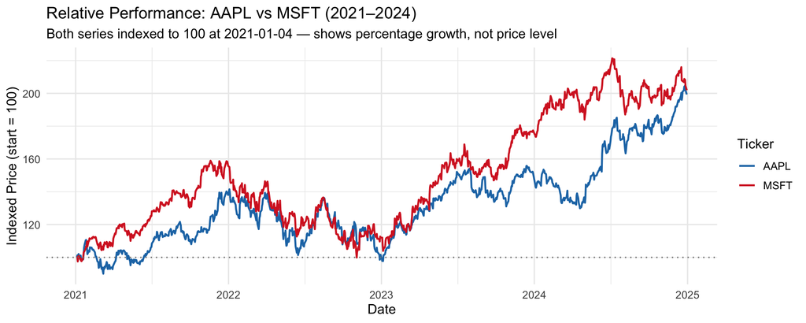

```r
# Index prices to 100 at the start date so relative performance is directly comparable.
# Raw prices differ in level (AAPL ~$130 vs MSFT ~$220 at start), which would make
# one series appear visually flatter even if its percentage moves are identical.
df_prices <- data.frame(
  date         = rep(dates, 2),
  price        = c(price_aapl, price_msft),
  price_indexed = c(price_aapl / price_aapl[1] * 100,
                    price_msft / price_msft[1] * 100),
  ticker       = rep(c("AAPL", "MSFT"), each = length(dates))
)

ggplot(df_prices, aes(x = date, y = price_indexed, colour = ticker)) +
  geom_line(linewidth = 0.8) +
  geom_hline(yintercept = 100, linetype = "dotted", colour = "grey50") +
  scale_colour_manual(values = c("AAPL" = "#1f77b4", "MSFT" = "#d62728")) +
  labs(title    = "Relative Performance: AAPL vs MSFT (2021–2024)",
       subtitle = "Both series indexed to 100 at 2021-01-04 — shows percentage growth, not price level",
       x = "Date", y = "Indexed Price (start = 100)", colour = "Ticker") +
  theme_minimal(base_size = 12)
```

## 2.3 Logarithmic Daily Returns

Daily log-returns are defined as:

$$r_t =
\ln\!\left(\frac{P_t}{P_{t-1}}\right)$$

Log-returns are preferred over simple returns because they are **time-additive** and tend to be closer to normally distributed for short horizons.

```r
ret_aapl  <- diff(log(price_aapl))
ret_msft  <- diff(log(price_msft))
ret_dates <- dates[-1]
n         <- length(ret_aapl)

# Summary table
summary_df <- data.frame(
  Ticker = c("AAPL", "MSFT"),
  N      = c(n, n),
  Mean   = c(mean(ret_aapl), mean(ret_msft)),
  SD     = c(sd(ret_aapl),   sd(ret_msft)),
  Min    = c(min(ret_aapl),  min(ret_msft)),
  Max    = c(max(ret_aapl),  max(ret_msft)),
  Skewness = c(skewness(ret_aapl), skewness(ret_msft)),
  ExKurtosis = c(kurtosis(ret_aapl) - 3, kurtosis(ret_msft) - 3)
)

kable(summary_df, digits = 6,
      caption = "Descriptive Statistics of Daily Log-Returns",
      col.names = c("Ticker","N","Mean","Std Dev","Min","Max","Skewness","Ex. Kurtosis")) |>
  kable_styling(bootstrap_options = c("striped","hover","condensed"), full_width = FALSE)
```

Descriptive Statistics of Daily Log-Returns

| Ticker | N | Mean | Std Dev | Min | Max | Skewness | Ex. Kurtosis |
| --- | --- | --- | --- | --- | --- | --- | --- |
| AAPL | 1003 | 0.000688 | 0.016737 | -0.060471 | 0.085237 | 0.046734 | 1.916832 |
| MSFT | 1003 | 0.000700 | 0.016429 | -0.080295 | 0.079059 | -0.113834 | 1.938065 |

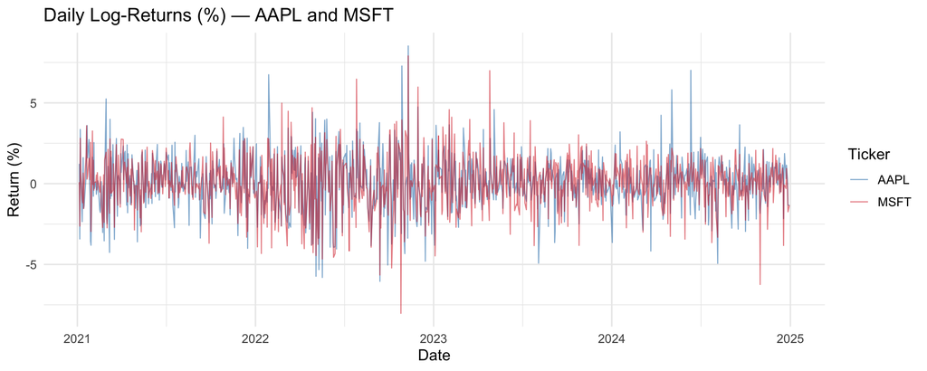

```r
df_ret <- data.frame(
  date   = rep(ret_dates, 2),
  ret    = c(ret_aapl, ret_msft) * 100,
  ticker = rep(c("AAPL","MSFT"), each = n)
)

ggplot(df_ret, aes(x = date, y = ret, colour = ticker)) +
  geom_line(alpha = 0.55, linewidth = 0.4) +
  scale_colour_manual(values = c("AAPL" = "#1f77b4", "MSFT" = "#d62728")) +
  labs(title  = "Daily Log-Returns (%) — AAPL and MSFT",
       x = "Date", y = "Return (%)", colour = "Ticker") +
  theme_minimal(base_size = 12)
```

## 2.4 Rolling Volatility

Daily returns tell us about individual days, but the variance permutation test in Section 3 asks about *average* volatility over the entire period. The rolling volatility chart below shows that this average masks considerable time variation — both stocks went through distinct high- and low-volatility regimes. The permutation test result should be read in this context: it tests equality of the unconditional variance, not whether the two stocks have similar volatility *at every point in time*.

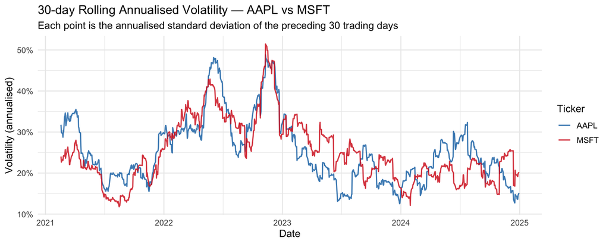

```r
library(zoo)

roll_vol <- data.frame(
  date = ret_dates[-(1:29)],
  AAPL = rollapply(ret_aapl, 30, sd) * sqrt(252),
  MSFT = rollapply(ret_msft, 30, sd) * sqrt(252)
) |> tidyr::pivot_longer(-date, names_to = "ticker", values_to = "vol")

ggplot(roll_vol, aes(x = date, y = vol, colour = ticker)) +
  geom_line(linewidth = 0.7, alpha = 0.85) +
  scale_colour_manual(values = c("AAPL" = "#1f77b4", "MSFT" = "#d62728")) +
  scale_y_continuous(labels = scales::percent_format()) +
  labs(title    = "30-day Rolling Annualised Volatility — AAPL vs MSFT",
       subtitle = "Each point is the annualised standard deviation of the preceding 30 trading days",
       x = "Date", y = "Volatility (annualised)", colour = "Ticker") +
  theme_minimal(base_size = 12)
```

# 3. Permutation Tests

Permutation tests are **non-parametric** inference procedures. They require no distributional assumptions. The key idea is:

> Under the null hypothesis the observed test statistic should be no more extreme than what we would expect by **random reassignment** of the data.

We use **N = 10,000 permutations** for all tests. All p-values are two-sided.

```r
N_PERM   <- 10000
combined <- c(ret_aapl, ret_msft)   # pooled sample (used in tests 3b and 3c)
```

## 3.1 Test of Covariance Significance

### Hypotheses

$$H_0: \text{Cov}(r_{\text{AAPL}},\,
r_{\text{MSFT}}) = 0 \quad \text{(returns are linearly
independent)}$$

$$H_1: \text{Cov}(r_{\text{AAPL}},\,
r_{\text{MSFT}}) \neq 0 \quad \text{(returns are linearly
associated)}$$

**Test statistic:** $T = \widehat{\text{Cov}}(r_{\text{AAPL}},\, r_{\text{MSFT}})$

Under $H_0$ the pairing between the two series is arbitrary, so we break it by randomly permuting one series. The permutation distribution approximates the sampling distribution of the covariance under $H_0$.

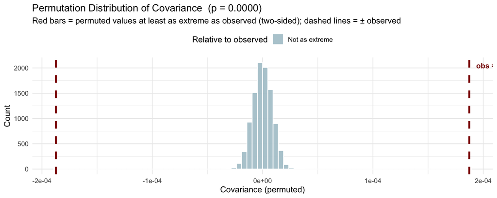

```r
obs_cov  <- cov(ret_aapl, ret_msft)
perm_cov <- replicate(N_PERM, cov(sample(ret_aapl), ret_msft))
p_val_cov <- mean(abs(perm_cov) >= abs(obs_cov))

# Shade bars that are at least as extreme as the observed statistic (two-sided).
# This makes the p-value visually intuitive: shaded area / total area = p-value.
df_perm_cov <- data.frame(cov = perm_cov)
df_perm_cov$extreme <- abs(df_perm_cov$cov) >= abs(obs_cov)

ggplot(df_perm_cov, aes(x = cov, fill = extreme)) +
  geom_histogram(bins = 80, colour = "white", alpha = 0.9) +
  scale_fill_manual(values = c("FALSE" = "#aec6cf", "TRUE" = "#e63946"),
                    labels = c("FALSE" = "Not as extreme", "TRUE" = "As extreme or more"),
                    name   = "Relative to observed") +
  geom_vline(xintercept =  obs_cov, colour = "darkred", linewidth = 1.3, linetype = "dashed") +
  geom_vline(xintercept = -obs_cov, colour = "darkred", linewidth = 1.3, linetype = "dashed") +
  annotate("text", x = obs_cov, y = Inf,
           label = sprintf("  obs = %.2e", obs_cov),
           vjust = 2, hjust = -0.05, colour = "darkred", size = 3.8, fontface = "bold") +
  labs(title    = sprintf("Permutation Distribution of Covariance  (p = %.4f)", p_val_cov),
       subtitle = "Red bars = permuted values at least as extreme as observed (two-sided); dashed lines = ± observed",
       x = "Covariance (permuted)", y = "Count") +
  theme_minimal(base_size = 12) +
  theme(legend.position = "top")
```

```r
cat(sprintf("Observed covariance:  %.2e\n", obs_cov))
```

```
## Observed covariance:  1.87e-04
```

```r
cat(sprintf("Permutation p-value:  %.4f\n", p_val_cov))
```

```
## Permutation p-value:  0.0000
```

```r
cat(sprintf("Decision (alpha=0.05): %s\n",
            ifelse(p_val_cov < 0.05, "REJECT H0", "FAIL TO REJECT H0")))
```

```
## Decision (alpha=0.05): REJECT H0
```

### Interpretation

The observed covariance is **1.87e-04**. Under H₀ (returns are independent), permuting the time-pairing of one series should produce covariances scattered symmetrically around zero — which is exactly what the histogram shows. The proportion of permuted covariances at least as extreme as the observed one (red bars) is the p-value: **p = 0**.

Since p < 0.05, we **reject H₀**. In all 10,000 random reshufflings of the data, not a single permuted covariance was as large as the observed value — the observed covariance lies completely outside the permutation distribution. This is overwhelming evidence that the co-movement of AAPL and MSFT returns is not a chance artefact. Economically, both are large-cap US tech stocks exposed to the same macro drivers (interest rates, risk sentiment, sector rotation), so a positive dependence is expected.

## 3.2 Test of Equality of Variances

### Hypotheses

$$H_0: \sigma^2_{\text{AAPL}} =
\sigma^2_{\text{MSFT}} \quad \text{(equal return
volatility)}$$

$$H_1: \sigma^2_{\text{AAPL}} \neq
\sigma^2_{\text{MSFT}} \quad \text{(different
volatilities)}$$

**Test statistic:** $T = \ln\!\left(\hat\sigma^2_{\text{AAPL}} / \hat\sigma^2_{\text{MSFT}}\right)$

We use the **log-ratio** of sample variances (rather than the raw ratio) because it is symmetric under $H_0$ and has a more stable permutation distribution. Under $H_0$, the labels for each pair are exchangeable, and randomly swapping observations within each day should produce a ratio close to 1 (i.e., log-ratio close to 0).

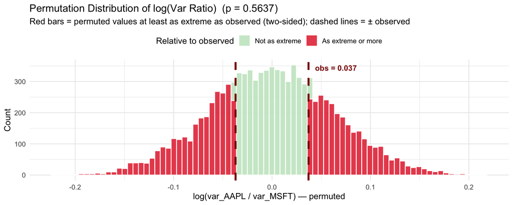

```r
# mean centering so that we test only variances
ret_aapl_c <- ret_aapl - mean(ret_aapl)
ret_msft_c <- ret_msft - mean(ret_msft)

obs_var_ratio  <- var(ret_aapl) / var(ret_msft)


perm_var_ratio <- replicate(N_PERM, {
  swap       <- sample(c(-1, 1), n, replace = TRUE)
  ret_a_perm <- ifelse(swap == 1, ret_aapl_c, ret_msft_c)
  ret_b_perm <- ifelse(swap == 1, ret_msft_c, ret_aapl_c)
  var(ret_a_perm) / var(ret_b_perm)
})

p_val_var <- mean(abs(log(perm_var_ratio)) >= abs(log(obs_var_ratio)))

df_perm_var <- data.frame(lr = log(perm_var_ratio))
df_perm_var$extreme <- abs(df_perm_var$lr) >= abs(log(obs_var_ratio))

ggplot(df_perm_var, aes(x = lr, fill = extreme)) +
  geom_histogram(bins = 80, colour = "white", alpha = 0.9) +
  scale_fill_manual(values = c("FALSE" = "#c8e6c9", "TRUE" = "#e63946"),
                    labels = c("FALSE" = "Not as extreme", "TRUE" = "As extreme or more"),
                    name   = "Relative to observed") +
  geom_vline(xintercept =  log(obs_var_ratio), colour = "darkred", linewidth = 1.3, linetype = "dashed") +
  geom_vline(xintercept = -log(obs_var_ratio), colour = "darkred", linewidth = 1.3, linetype = "dashed") +
  annotate("text", x = log(obs_var_ratio), y = Inf,
           label = sprintf("  obs = %.3f", log(obs_var_ratio)),
           vjust = 2, hjust = -0.05, colour = "darkred", size = 3.8, fontface = "bold") +
  labs(title    = sprintf("Permutation Distribution of log(Var Ratio)  (p = %.4f)", p_val_var),
       subtitle = "Red bars = permuted values at least as extreme as observed (two-sided); dashed lines = ± observed",
       x = "log(var_AAPL / var_MSFT) — permuted", y = "Count") +
  theme_minimal(base_size = 12) +
  theme(legend.position = "top")
```

```r
cat(sprintf("Observed variance — AAPL: %.2e\n", var(ret_aapl)))
```

```
## Observed variance — AAPL: 2.80e-04
```

```r
cat(sprintf("Observed variance — MSFT: %.2e\n", var(ret_msft)))
```

```
## Observed variance — MSFT: 2.70e-04
```

```r
cat(sprintf("Variance ratio (AAPL/MSFT): %.4f\n", obs_var_ratio))
```

```
## Variance ratio (AAPL/MSFT): 1.0377
```

```r
cat(sprintf("Permutation p-value:        %.4f\n", p_val_var))
```

```
## Permutation p-value:        0.5637
```

```r
cat(sprintf("Decision (alpha=0.05): %s\n",
            ifelse(p_val_var < 0.05, "REJECT H0", "FAIL TO REJECT H0")))
```

```
## Decision (alpha=0.05): FAIL TO REJECT H0
```

### Interpretation

The permutation p-value is **p = 0.5637**. Since p > 0.05, we **fail to reject H₀** — the data do not provide sufficient evidence to distinguish the two volatilities. We cannot rule out that the observed ratio is due to random variation.

## 3.3 Test of Equality of Expected Returns

### Hypotheses

$$H_0: \mu_{\text{AAPL}} =
\mu_{\text{MSFT}} \quad \text{(equal mean daily returns)}$$

$$H_1: \mu_{\text{AAPL}} \neq
\mu_{\text{MSFT}} \quad \text{(different mean daily
returns)}$$

**Test statistic:** $T = \bar r_{\text{AAPL}} - \bar r_{\text{MSFT}}$

Under $H_0$ the label “AAPL” vs “MSFT” is exchangeable; randomly reassigning observations to groups (swapping labels within each day) should produce differences near zero.

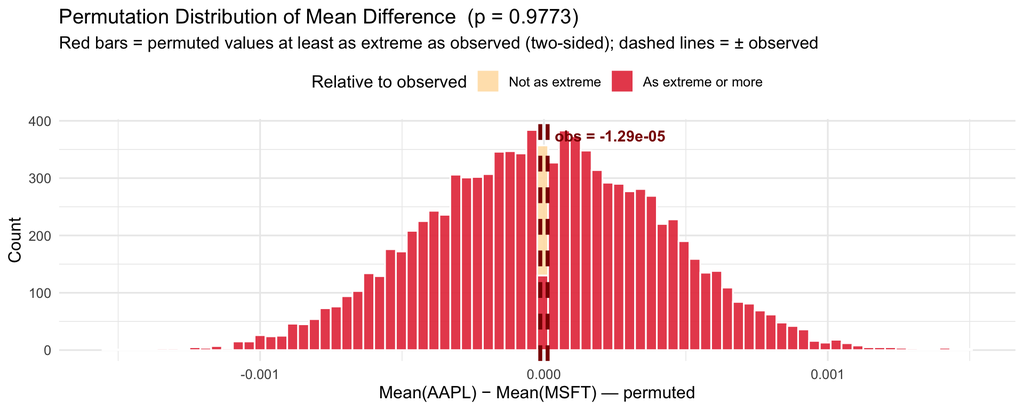

```r
obs_diff_mean  <- mean(ret_aapl) - mean(ret_msft)

diffs <- ret_aapl - ret_msft

perm_diff_mean <- replicate(N_PERM, {
  signs <- sample(c(-1, 1), n, replace = TRUE)
  mean(signs * diffs)
})

p_val_mean <- mean(abs(perm_diff_mean) >= abs(obs_diff_mean))

df_perm_mean <- data.frame(dm = perm_diff_mean)
df_perm_mean$extreme <- abs(df_perm_mean$dm) >= abs(obs_diff_mean)

ggplot(df_perm_mean, aes(x = dm, fill = extreme)) +
  geom_histogram(bins = 80, colour = "white", alpha = 0.9) +
  scale_fill_manual(values = c("FALSE" = "#ffe0b2", "TRUE" = "#e63946"),
                    labels = c("FALSE" = "Not as extreme", "TRUE" = "As extreme or more"),
                    name   = "Relative to observed") +
  geom_vline(xintercept =  obs_diff_mean, colour = "darkred", linewidth = 1.3, linetype = "dashed") +
  geom_vline(xintercept = -obs_diff_mean, colour = "darkred", linewidth = 1.3, linetype = "dashed") +
  annotate("text", x = obs_diff_mean, y = Inf,
           label = sprintf("  obs = %.2e", obs_diff_mean),
           vjust = 2, hjust = -0.05, colour = "darkred", size = 3.8, fontface = "bold") +
  labs(title    = sprintf("Permutation Distribution of Mean Difference  (p = %.4f)", p_val_mean),
       subtitle = "Red bars = permuted values at least as extreme as observed (two-sided); dashed lines = ± observed",
       x = "Mean(AAPL) − Mean(MSFT) — permuted", y = "Count") +
  theme_minimal(base_size = 12) +
  theme(legend.position = "top")
```

```r
cat(sprintf("Mean return AAPL: %.6f  (%.4f%% daily)\n",
            mean(ret_aapl), mean(ret_aapl)*100))
```

```
## Mean return AAPL: 0.000688  (0.0688% daily)
```

```r
cat(sprintf("Mean return MSFT: %.6f  (%.4f%% daily)\n",
            mean(ret_msft), mean(ret_msft)*100))
```

```
## Mean return MSFT: 0.000700  (0.0700% daily)
```

```r
cat(sprintf("Observed difference:      %.2e\n", obs_diff_mean))
```

```
## Observed difference:      -1.29e-05
```

```r
cat(sprintf("Permutation p-value:      %.4f\n", p_val_mean))
```

```
## Permutation p-value:      0.9773
```

```r
cat(sprintf("Decision (alpha=0.05): %s\n",
            ifelse(p_val_mean < 0.05, "REJECT H0", "FAIL TO REJECT H0")))
```

```
## Decision (alpha=0.05): FAIL TO REJECT H0
```

```r
tt <- t.test(ret_aapl, ret_msft, paired=T)
cat(sprintf("Paired t-test p-value (for comparison):  %.4f\n", tt$p.value))
```

```
## Paired t-test p-value (for comparison):  0.9754
```

### Interpretation

Since p > 0.05, we **fail to reject H₀** — the observed difference in mean returns is consistent with random variation. This is the typical result for large-cap stocks over horizons of a few years: daily mean returns are estimated with very high variance, making the test low-powered.

## 3.4 Summary of Permutation Tests

```r
perm_summary <- data.frame(
  Test         = c("Covariance significance",
                   "Equality of variances",
                   "Equality of expected returns"),
  H0           = c("Cov = 0", "σ²_AAPL = σ²_MSFT", "μ_AAPL = μ_MSFT"),
  Statistic    = c(round(obs_cov, 6),
                   round(obs_var_ratio, 4),
                   round(obs_diff_mean, 6)),
  p_value      = c(p_val_cov, p_val_var, p_val_mean),
  Decision     = c(ifelse(p_val_cov  < 0.05, "Reject H₀", "Fail to reject"),
                   ifelse(p_val_var  < 0.05, "Reject H₀", "Fail to reject"),
                   ifelse(p_val_mean < 0.05, "Reject H₀", "Fail to reject"))
)

kable(perm_summary, digits = 4,
      caption = "Permutation Test Results (N = 10,000, α = 0.05)",
      col.names = c("Test","Null Hypothesis H₀","Observed Statistic","p-value","Decision (α=0.05)")) |>
  kable_styling(bootstrap_options = c("striped","hover","condensed"), full_width = FALSE) |>
  column_spec(5, bold = TRUE,
              color = ifelse(perm_summary$p_value < 0.05, "red", "darkgreen"))
```

Permutation Test Results (N = 10,000, α = 0.05)

| Test | Null Hypothesis H₀ | Observed Statistic | p-value | Decision (α=0.05) |
| --- | --- | --- | --- | --- |
| Covariance significance | Cov = 0 | 0.0002 | 0.0000 | Reject H₀ |
| Equality of variances | σ²_AAPL = σ²_MSFT | 1.0377 | 0.5637 | Fail to reject |
| Equality of expected returns | μ_AAPL = μ_MSFT | 0.0000 | 0.9773 | Fail to reject |

# 4. Portfolio Profit Analysis

## 4.1 Strategy Description

For every trading day $t$ we **buy 100 shares of each stock** at the closing price and **sell them 100 trading days later**:

$$\Pi_t = 100 \cdot
(P^{\text{AAPL}}_{t+100} - P^{\text{AAPL}}_t) + 100 \cdot
(P^{\text{MSFT}}_{t+100} - P^{\text{MSFT}}_t)$$

Transaction costs are ignored. The result is a time series of overlapping 100-day holding-period profits. Since we are working on dependent observations (each window shares 99 days with its’neighbours), the descriptive statistics shown below should not be interpreted as if they came from an independent sample.

```r
N_SHARES  <- 100
HORIZON   <- 100

buy_idx   <- 1:(length(price_aapl) - HORIZON)
sell_idx  <- buy_idx + HORIZON

profit_aapl      <- N_SHARES * (price_aapl[sell_idx] - price_aapl[buy_idx])
profit_msft      <- N_SHARES * (price_msft[sell_idx] - price_msft[buy_idx])
profit_portfolio <- profit_aapl + profit_msft
n_port           <- length(profit_portfolio)

port_summary <- data.frame(
  Metric = c("N (windows)", "Mean profit (USD)", "Median profit (USD)",
             "Std Dev (USD)", "Min (USD)", "Max (USD)",
             "Skewness", "Excess Kurtosis"),
  Value  = c(n_port,
             round(mean(profit_portfolio), 2),
             round(median(profit_portfolio), 2),
             round(sd(profit_portfolio), 2),
             round(min(profit_portfolio), 2),
             round(max(profit_portfolio), 2),
             round(skewness(profit_portfolio), 4),
             round(kurtosis(profit_portfolio) - 3, 4))
)

kable(port_summary, caption = "Descriptive Statistics — Portfolio Profit") |>
  kable_styling(bootstrap_options = c("striped","hover"), full_width = FALSE)
```

Descriptive Statistics — Portfolio Profit

| Metric | Value |
| --- | --- |
| N (windows) | 904.0000 |
| Mean profit (USD) | 3245.7900 |
| Median profit (USD) | 4054.5500 |
| Std Dev (USD) | 5517.7900 |
| Min (USD) | -12679.2600 |
| Max (USD) | 15751.5900 |
| Skewness | -0.4107 |
| Excess Kurtosis | -0.2358 |

The graphs below show return distribution.

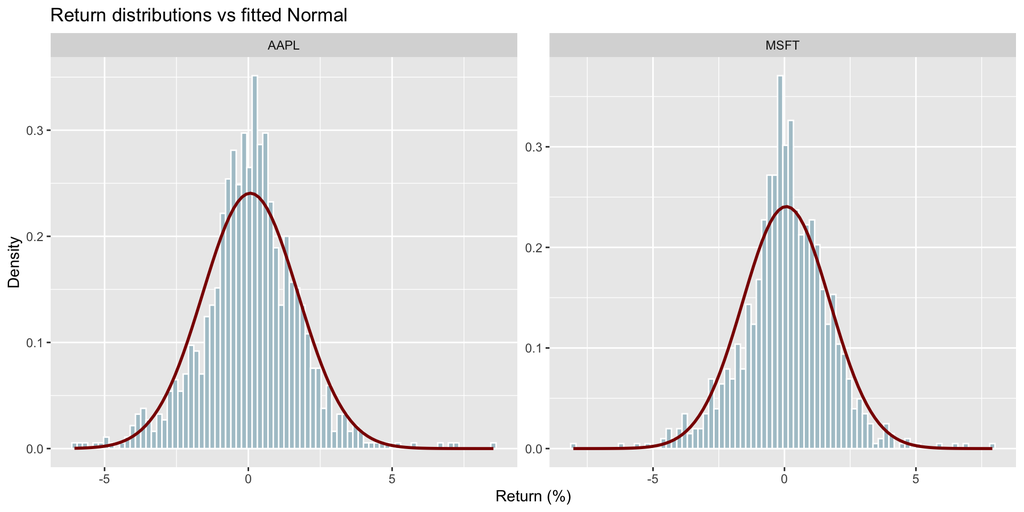

```r
ggplot(df_ret, aes(x = ret)) +
  geom_histogram(aes(y = after_stat(density)), bins = 80,
                 fill = "#aec6cf", colour = "white") +
  stat_function(fun = dnorm,
                args = list(mean = mean(df_ret$ret), sd = sd(df_ret$ret)),
                colour = "darkred", linewidth = 1) +
  facet_wrap(~ticker, scales = "free") +
  labs(title = "Return distributions vs fitted Normal",
       x = "Return (%)", y = "Density")
```

### Overlapping Windows and Effective Sample Size

Although we have 904 profit observations, consecutive windows share 99 out of 100 days of price data — window $t$ and window $t+1$ differ only in that one day is dropped at the start and one is added at the end. This induces autocorrelation in the profit series that persists for approximately 100 lags. The number of approximately independent observations is closer to 9 (one per non-overlapping horizon).

Switching to non-overlapping windows would reduce $n$ to ~9, making tail quantiles undefined and the histogram uninformative, hence we retain the overlapping design.

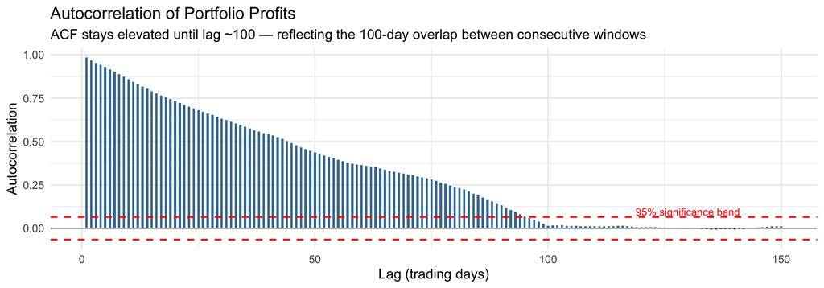

```r
acf_vals <- acf(profit_portfolio, lag.max = 150, plot = FALSE)

ggplot(data.frame(lag  = 1:150,
                  acf  = as.numeric(acf_vals$acf[-1])),
       aes(x = lag, y = acf)) +
  geom_col(width = 0.5, fill = "#457b9d") +
  geom_hline(yintercept =  1.96 / sqrt(n_port),
             linetype = "dashed", colour = "red", linewidth = 0.7) +
  geom_hline(yintercept = -1.96 / sqrt(n_port),
             linetype = "dashed", colour = "red", linewidth = 0.7) +
  geom_hline(yintercept = 0, colour = "grey40", linewidth = 0.4) +
  annotate("text", x = 130, y = 1.96 / sqrt(n_port) + 0.03,
           label = "95% significance band", colour = "red", size = 3.2) +
  labs(title    = "Autocorrelation of Portfolio Profits",
       subtitle = paste0("ACF stays elevated until lag ~", HORIZON,
                         " — reflecting the 100-day overlap between consecutive windows"),
       x = "Lag (trading days)", y = "Autocorrelation") +
  theme_minimal(base_size = 12)
```

## 4.2 Profit Distribution vs Normal

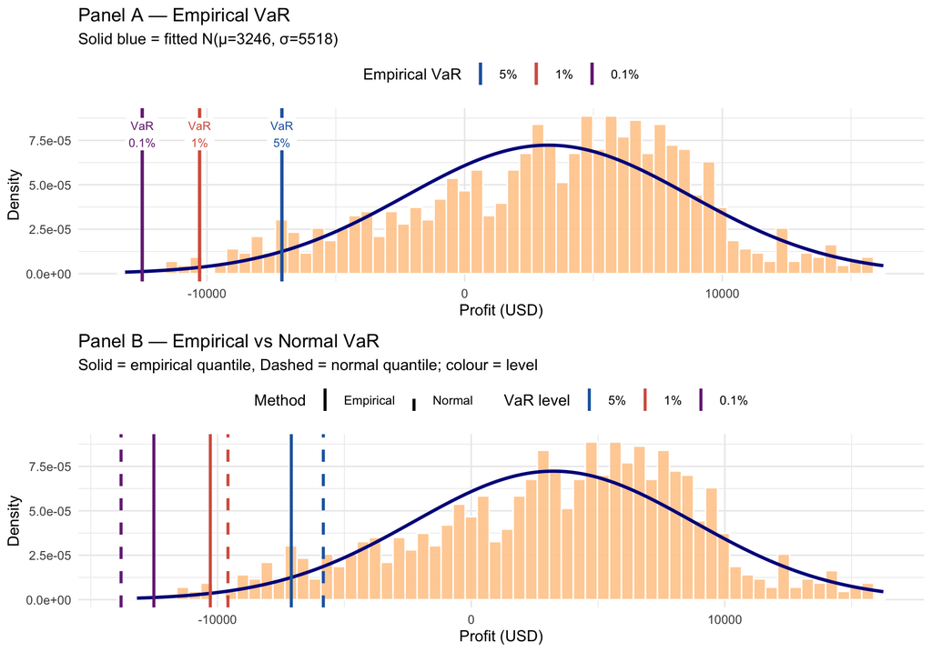

```r
mu_port  <- mean(profit_portfolio)
sd_port  <- sd(profit_portfolio)
x_seq    <- seq(min(profit_portfolio) - 500, max(profit_portfolio) + 500, length.out = 600)
df_norm  <- data.frame(x = x_seq, y = dnorm(x_seq, mu_port, sd_port))

bw <- (max(profit_portfolio) - min(profit_portfolio)) / 60

alpha_levels <- c(0.05, 0.01, 0.001)
var_emp  <- quantile(profit_portfolio, probs = alpha_levels)
var_norm <- qnorm(alpha_levels, mean = mu_port, sd = sd_port)

# --- Panel 1: Empirical VaR ---
# Each VaR level gets its own distinct colour from a colourblind-friendly palette.
emp_lines <- data.frame(
  x     = var_emp,
  level = factor(c("5%", "1%", "0.1%"), levels = c("5%", "1%", "0.1%"))
)

p1 <- ggplot(data.frame(profit = profit_portfolio), aes(x = profit)) +
  geom_histogram(aes(y = after_stat(density)), binwidth = bw,
                 fill = "#ffcc99", colour = "white", alpha = 0.9) +
  geom_line(data = df_norm, aes(x = x, y = y),
            colour = "darkblue", linewidth = 1.2, linetype = "solid") +
  geom_vline(data = emp_lines, aes(xintercept = x, colour = level),
             linewidth = 1.2) +
  geom_label(data = emp_lines,
             aes(x = x, y = Inf, label = paste0("VaR\n", level), colour = level),
             vjust = 1.3, size = 3.2, fill = "white", label.size = 0, show.legend = FALSE) +
  scale_colour_manual(values = c("5%" = "#2166ac", "1%" = "#d6604d", "0.1%" = "#762a83"),
                      name = "Empirical VaR") +
  labs(title    = "Panel A — Empirical VaR",
       subtitle = sprintf("Solid blue = fitted N(μ=%.0f, σ=%.0f)", mu_port, sd_port),
       x = "Profit (USD)", y = "Density") +
  theme_minimal(base_size = 12) +
  theme(legend.position = "top")

# --- Panel 2: Empirical vs Normal VaR comparison ---
# Pair each level's empirical and normal VaR side by side using different linetypes.
both_lines <- data.frame(
  x      = c(var_emp, var_norm),
  level  = rep(factor(c("5%", "1%", "0.1%"), levels = c("5%", "1%", "0.1%")), 2),
  method = rep(c("Empirical", "Normal"), each = 3)
)

p2 <- ggplot(data.frame(profit = profit_portfolio), aes(x = profit)) +
  geom_histogram(aes(y = after_stat(density)), binwidth = bw,
                 fill = "#ffcc99", colour = "white", alpha = 0.9) +
  geom_line(data = df_norm, aes(x = x, y = y),
            colour = "darkblue", linewidth = 1.2) +
  geom_vline(data = both_lines,
             aes(xintercept = x, colour = level, linetype = method),
             linewidth = 1.1) +
  scale_colour_manual(values = c("5%" = "#2166ac", "1%" = "#d6604d", "0.1%" = "#762a83"),
                      name = "VaR level") +
  scale_linetype_manual(values = c("Empirical" = "solid", "Normal" = "dashed"),
                        name = "Method") +
  labs(title    = "Panel B — Empirical vs Normal VaR",
       subtitle = "Solid = empirical quantile, Dashed = normal quantile; colour = level",
       x = "Profit (USD)", y = "Density") +
  theme_minimal(base_size = 12) +
  theme(legend.position = "top")

grid.arrange(p1, p2, nrow = 2)
```

```r
# Empirical ES
es_emp <- sapply(alpha_levels, function(a) {
  threshold <- quantile(profit_portfolio, probs = a)
  mean(profit_portfolio[profit_portfolio <= threshold])
})

# Normal ES
# For a normal distribution: ES_alpha = mu - sigma * phi(z_alpha) / alpha
# where phi is the standard normal PDF and z_alpha is the standard normal quantile
es_norm <- sapply(alpha_levels, function(a) {
  z <- qnorm(a)
  mu_port - sd_port * dnorm(z) / a
})
```

### Shapiro–Wilk Normality Test

We formally test whether portfolio profits follow a normal distribution.

**Hypotheses:**

$$H_0: \text{Portfolio profit is normally
distributed}$$
$$H_1: \text{Portfolio
profit is NOT normally distributed}$$

```r
# we use only every 100th observation — these are approximately independent
non_overlap_idx <- seq(1, n_port, by = HORIZON)
profit_indep    <- profit_portfolio[non_overlap_idx]

cat(sprintf("Non-overlapping windows: %d\n", length(profit_indep)))
```

```
## Non-overlapping windows: 10
```

```r
sw <- shapiro.test(profit_indep)

cat(sprintf("Shapiro–Wilk test: W = %.5f,  p-value = %.4e\n", sw$statistic, sw$p.value))
```

```
## Shapiro–Wilk test: W = 0.95088,  p-value = 6.7896e-01
```

```r
cat(sprintf("Decision (alpha=0.05): %s\n",
            ifelse(sw$p.value < 0.05, "REJECT H0 — non-normal", "FAIL TO REJECT H0 — consistent with normal")))
```

```
## Decision (alpha=0.05): FAIL TO REJECT H0 — consistent with normal
```

### Q–Q Plot

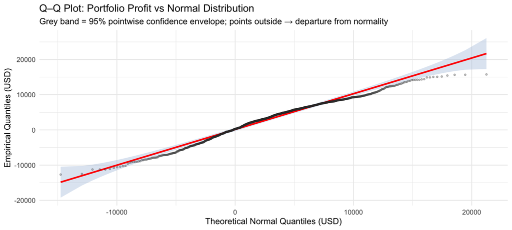

```r
# The grey band is a 95% pointwise confidence envelope for the normal Q-Q plot.
# Points inside the band are consistent with normality; points outside indicate departures.
ggplot(data.frame(profit = profit_portfolio), aes(sample = profit)) +
  stat_qq_band(distribution = "norm",
               dparams = list(mean = mu_port, sd = sd_port),
               fill = "#b0c4de", alpha = 0.4) +
  stat_qq_line(distribution = "norm",
               dparams = list(mean = mu_port, sd = sd_port),
               colour = "red", linewidth = 1.1) +
  stat_qq_point(distribution = "norm",
                dparams = list(mean = mu_port, sd = sd_port),
                alpha = 0.3, size = 0.9, colour = "#333333") +
  labs(title    = "Q–Q Plot: Portfolio Profit vs Normal Distribution",
       subtitle = "Grey band = 95% pointwise confidence envelope; points outside → departure from normality",
       x = "Theoretical Normal Quantiles (USD)", y = "Empirical Quantiles (USD)") +
  theme_minimal(base_size = 12)
```

# 5. Value at Risk (VaR) and Expected Shortfall (ES)

**Value at Risk at level $\alpha$** is the threshold loss such that the probability of the portfolio return falling *below* it is $\alpha$:

$$\text{VaR}_\alpha = Q_\alpha(\Pi) \quad
\text{i.e.,} \quad P(\Pi \leq \text{VaR}_\alpha) = \alpha$$

A *negative* VaR denotes a loss. We compute two variants:

- **Empirical VaR:** the empirical $\alpha$-quantile of observed profits.
- **Normal VaR:** the $\alpha$-quantile of $\mathcal{N}(\hat\mu, \hat\sigma^2)$ fitted to the data.

**Expected Shortfall (ES) at level $\alpha$** — also called Conditional VaR — is the average loss in the worst $\alpha$% of scenarios:
$$ES_\alpha = E[\Pi \mid \Pi \leq
\text{VaR}_\alpha]$$
It is reported alongside VaR as it better captures the severity of tail losses, not just their threshold.

```r
var_es_df <- data.frame(
  Level        = c("5%", "1%", "0.1%"),
  Empirical_VaR = round(var_emp, 2),
  Normal_VaR    = round(var_norm, 2),
  Difference    = round(var_emp - var_norm, 2),
  Empirical_ES  = round(es_emp, 2),
  Normal_ES     = round(es_norm, 2)
)

kable(var_es_df, caption = "Value at Risk — Empirical vs Normal (USD)",
      col.names = c("Confidence Level", "Empirical VaR (USD)",
                    "Normal VaR (USD)", "Difference (Emp − Norm)",
                    "Empirical ES (USD)", "Normal ES (USD)")) |>
  kable_styling(bootstrap_options = c("striped","hover","condensed"), full_width = FALSE)
```

Value at Risk — Empirical vs Normal (USD)

|  | Confidence Level | Empirical VaR (USD) | Normal VaR (USD) | Difference (Emp − Norm) | Empirical ES (USD) | Normal ES (USD) |
| --- | --- | --- | --- | --- | --- | --- |
| 5% | 5% | -7092.02 | -5830.18 | -1261.84 | -8819.70 | -8135.84 |
| 1% | 1% | -10286.24 | -9590.52 | -695.72 | -11212.91 | -11460.32 |
| 0.1% | 0.1% | -12512.38 | -13805.48 | 1293.10 | -12679.26 | -15333.12 |

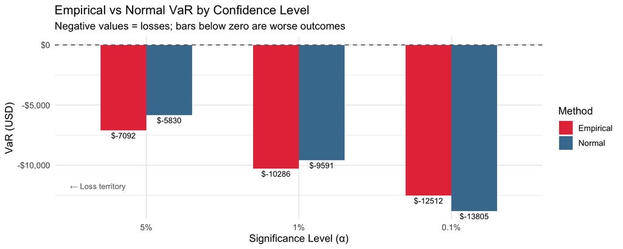

```r
var_comp <- data.frame(
  level  = rep(c("5%","1%","0.1%"), 2),
  method = rep(c("Empirical","Normal"), each = 3),
  value  = c(var_emp, var_norm)
)
var_comp$level <- factor(var_comp$level, levels = c("5%","1%","0.1%"))

ggplot(var_comp, aes(x = level, y = value, fill = method)) +
  geom_col(position = "dodge", width = 0.6) +
  geom_text(aes(label = sprintf("$%.0f", value),
                vjust = ifelse(value < 0, 1.4, -0.4)),
            position = position_dodge(width = 0.6), size = 3.2) +
  geom_hline(yintercept = 0, linetype = "dashed", colour = "grey40") +
  scale_fill_manual(values = c("Empirical" = "#e63946", "Normal" = "#457b9d")) +
  scale_y_continuous(labels = scales::dollar_format()) +
  annotate("text", x = 0.5, y = min(c(var_emp, var_norm)) * 0.85,
           label = "← Loss territory", hjust = 0, size = 3.2, colour = "grey40") +
  labs(title    = "Empirical vs Normal VaR by Confidence Level",
       subtitle = "Negative values = losses; bars below zero are worse outcomes",
       x = "Significance Level (α)", y = "VaR (USD)", fill = "Method") +
  theme_minimal(base_size = 12)
```

### Interpretation

[output not shown]

# 6. Conclusions

```r
conclusions <- data.frame(
  Question = c(
    "Are AAPL and MSFT returns linearly dependent?",
    "Do they have equal volatility?",
    "Do they have equal expected returns?",
    "Is the portfolio profit normally distributed?",
    "Does normal VaR capture tail risk accurately?"
  ),
  Finding = c(
    ifelse(p_val_cov  < 0.05,
           paste0("Yes — covariance is significant (p = ", round(p_val_cov, 4), ")"),
           paste0("No evidence — covariance not significant (p = ", round(p_val_cov, 4), ")")),
    ifelse(p_val_var  < 0.05,
           paste0("No — variances differ significantly (p = ", round(p_val_var, 4), ")"),
           paste0("Possibly — no significant difference (p = ", round(p_val_var, 4), ")")),
    ifelse(p_val_mean < 0.05,
           paste0("No — means differ significantly (p = ", round(p_val_mean, 4), ")"),
           paste0("Possibly — no significant difference (p = ", round(p_val_mean, 4), ")")),
    ifelse(sw$p.value < 0.05,
           paste0("No — Shapiro–Wilk rejects normality (p = ", formatC(sw$p.value, format='e', digits=1), ")"),
           paste0("Consistent with normal (p = ", round(sw$p.value, 4), ")")),
    ifelse(abs(var_emp[3]) > abs(var_norm[3]),
           "No — normal VaR underestimates extreme losses (fat tails)",
           "Approximately yes — normal VaR is close to empirical")
  )
)

kable(conclusions, caption = "Summary of Key Findings",
      col.names = c("Question", "Finding")) |>
  kable_styling(bootstrap_options = c("striped","hover"), full_width = FALSE) |>
  column_spec(1, bold = TRUE, width = "40%") |>
  column_spec(2, width = "60%")
```

Summary of Key Findings

| Question | Finding |
| --- | --- |
| Are AAPL and MSFT returns linearly dependent? | Yes — covariance is significant (p = 0) |
| Do they have equal volatility? | Possibly — no significant difference (p = 0.5637) |
| Do they have equal expected returns? | Possibly — no significant difference (p = 0.9773) |
| Is the portfolio profit normally distributed? | Consistent with normal (p = 0.679) |
| Does normal VaR capture tail risk accurately? | Approximately yes — normal VaR is close to empirical |

*Report generated with R 4.5.3 · quantmod · ggplot2 · moments*